# ProjektObliczeniowy

For data normalization, string entries changed to numerical values according to: a) Gender:

```
- M - 0
- K - 1
```

b) Group:

```
- E - 0
- M - 1
```

b) Theory status:

```
- ZWOL - 2
- ZAL - 1
- NZAL - 0
```

C) Zad status:

```
- ZWOL - 2
- ZAL - 1
- NZAL - 0
```

```python
import numpy as np
import pandas as pd
import matplotlib.pyplot as plt
from imblearn.over_sampling import SMOTE, RandomOverSampler
from sklearn.model_selection import train_test_split
from sklearn.preprocessing import Normalizer
from sklearn.impute import SimpleImputer
from sklearn.naive_bayes import GaussianNB, MultinomialNB, BernoulliNB
from sklearn.neighbors import KNeighborsClassifier
from sklearn.tree import DecisionTreeClassifier
from sklearn.ensemble import RandomForestClassifier

import sklearn.metrics as metrics
import seaborn as sns
```

```python
data = pd.read_csv("/Users/Olga/Jupyter_files/Dane.csv", index_col = "LP")
```

```python
#data description without filling NA values not to skew results
data.describe(include=[np.number])
```

|  | GENDER | GROUP | K1T | M1T | K1T_FINAL | K2T | M2T | K2T_FINAL | K3T | K3T_FINAL | ... | K2Z_PKT | K3Z_PKT | ZAD_PKT | ZAD_ZAL | ZAD_STATUS | E1Z | E2Z | E3Z | EZ_FINAL_PKT | AVERAGE |
| --- | --- | --- | --- | --- | --- | --- | --- | --- | --- | --- | --- | --- | --- | --- | --- | --- | --- | --- | --- | --- | --- |
| count | 132.000000 | 132.000000 | 120.000000 | 57.000000 | 124.000000 | 111.000000 | 70.000000 | 121.000000 | 111.000000 | 132.000000 | ... | 132.000000 | 132.000000 | 132.000000 | 132.000000 | 132.000000 | 62.000000 | 52.000000 | 27.000000 | 132.000000 | 132.000000 |
| mean | 0.227273 | 0.257576 | 2.856250 | 3.210526 | 3.247984 | 2.713964 | 3.025000 | 3.126033 | 3.240991 | 3.043561 | ... | 3.823864 | 3.149621 | 10.471591 | 2.000000 | 1.060606 | 2.354839 | 3.336538 | 3.842593 | 3.741061 | 3.422955 |
| std | 0.420667 | 0.438965 | 0.689555 | 0.626408 | 0.602751 | 0.670691 | 0.759183 | 0.675558 | 0.728423 | 0.808174 | ... | 1.074842 | 1.131548 | 2.698361 | 1.062907 | 0.798449 | 0.573579 | 0.878508 | 0.973564 | 1.021492 | 0.922745 |
| min | 0.000000 | 0.000000 | 2.000000 | 2.000000 | 2.000000 | 2.000000 | 2.000000 | 2.000000 | 2.000000 | 2.000000 | ... | 2.000000 | 2.000000 | 6.000000 | 0.000000 | 0.000000 | 2.000000 | 2.000000 | 2.000000 | 2.000000 | 2.000000 |
| 25% | 0.000000 | 0.000000 | 2.250000 | 2.750000 | 2.937500 | 2.000000 | 2.250000 | 2.750000 | 2.750000 | 2.250000 | ... | 3.000000 | 2.000000 | 8.500000 | 1.000000 | 0.000000 | 2.000000 | 2.500000 | 3.125000 | 3.000000 | 2.000000 |
| 50% | 0.000000 | 0.000000 | 2.750000 | 3.250000 | 3.250000 | 2.500000 | 3.000000 | 3.000000 | 3.250000 | 3.000000 | ... | 4.250000 | 2.750000 | 10.750000 | 2.000000 | 1.000000 | 2.000000 | 3.250000 | 4.000000 | 4.040000 | 3.650000 |
| 75% | 0.000000 | 1.000000 | 3.250000 | 3.500000 | 3.500000 | 3.250000 | 3.500000 | 3.500000 | 3.750000 | 3.500000 | ... | 4.750000 | 4.250000 | 12.562500 | 3.000000 | 2.000000 | 2.500000 | 4.000000 | 4.500000 | 4.500000 | 4.130000 |
| max | 1.000000 | 1.000000 | 4.750000 | 4.750000 | 4.750000 | 4.500000 | 5.000000 | 5.000000 | 5.000000 | 5.000000 | ... | 5.000000 | 5.000000 | 15.000000 | 3.000000 | 2.000000 | 4.250000 | 5.000000 | 5.000000 | 5.000000 | 4.880000 |

8 rows × 38 columns

```python
#set number of rows for multiple plots to used in plotting results
def choose_grid(nr):
    return nr // 2, 2
```

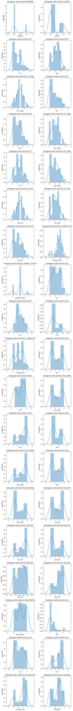

```python
#print histograms for each column in dataset before filling NaN values

columns = data.select_dtypes(include='number').columns
rows, cols = choose_grid(len(columns))
plt.figure()
fig, axs = plt.subplots(rows, cols, figsize=(cols*4, rows*4), squeeze=False)
i, j = 0, 0
changed_label = ['GENDER', 'GROUP', 'THEORY_STATUS']
for n in range(len(columns)):
    axs[i, j].set_title('Histogram with trend for %s'%columns[n])
    axs[i, j].set_ylabel("probability")
    sns.distplot(data[columns[n]].dropna().values, norm_hist=True, ax=axs[i, j], axlabel=columns[n])
    i, j = (i + 1, 0) if (n+1) % cols == 0 else (i, j + 1)
fig.tight_layout()
plt.show()
```

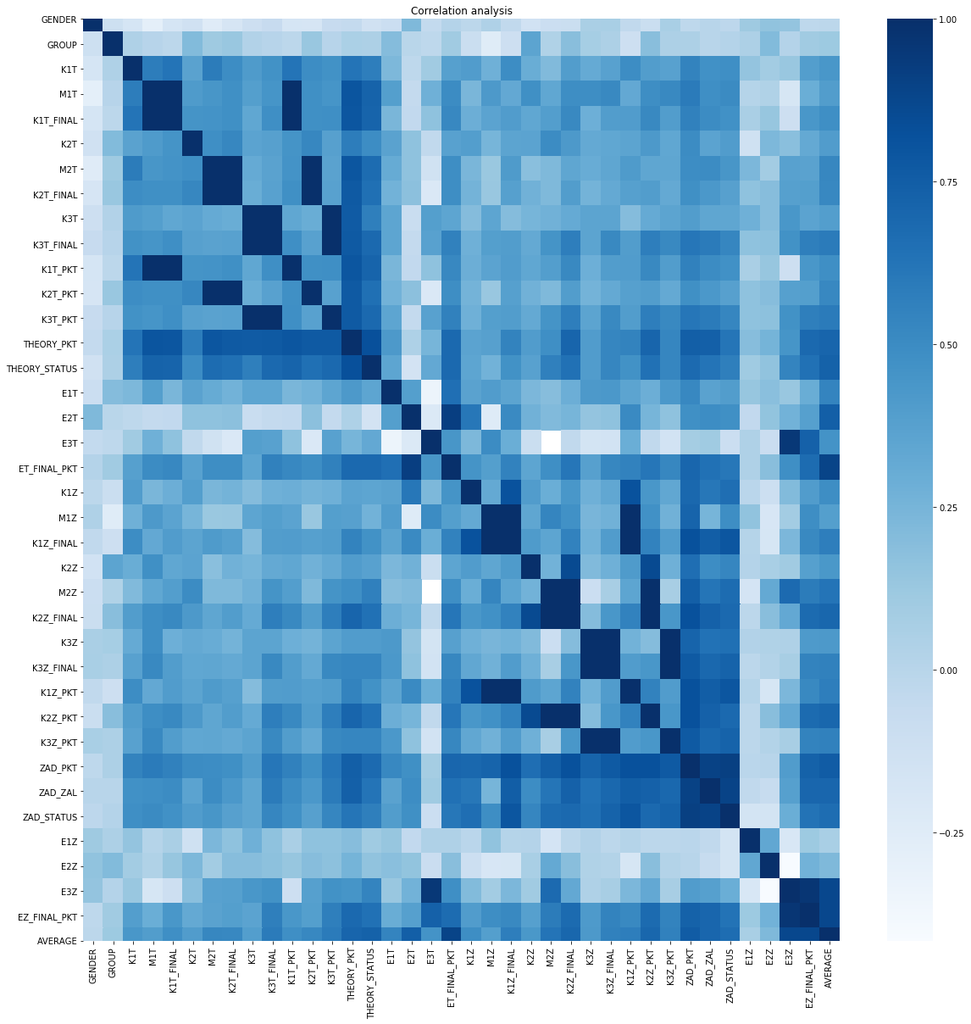

```python
#plot correlation for all parameters, drop irrelevant columns

fig = plt.figure(figsize=[20, 20])
corr_mtx = data.corr()
sns.heatmap(corr_mtx, xticklabels=corr_mtx.columns, yticklabels=corr_mtx.columns, annot=False, cmap='Blues')
plt.title('Correlation analysis')
plt.show()
```

```python
#first 5 entries without filling NaN values
print(data.head())
```

```
    GENDER  GROUP  K1T  M1T  K1T_FINAL   K2T  M2T  K2T_FINAL   K3T  K3T_FINAL  \
LP
1        0      1  4.0  NaN        4.0  3.50  4.5       4.50  2.25       2.25
2        0      0  4.0  NaN        4.0  3.50  4.0       4.00  4.50       4.50
3        0      0  3.5  NaN        3.5  3.00  NaN       3.00  2.00       2.00
4        0      0  4.5  NaN        4.5  4.00  NaN       4.00  3.50       3.50
5        0      0  3.0  4.5        4.5  3.75  NaN       3.75  3.75       3.75

    ...  K2Z_PKT  K3Z_PKT  ZAD_PKT  ZAD_ZAL  ZAD_STATUS  E1Z   E2Z  E3Z  \
LP  ...
1   ...     5.00     5.00    15.00      3.0           2  NaN   NaN  NaN
2   ...     4.75     4.00    13.75      3.0           2  NaN   NaN  NaN
3   ...     2.50     3.00    10.25      2.0           1  2.0  2.25  3.5
4   ...     4.25     4.75    14.00      3.0           2  NaN   NaN  NaN
5   ...     5.00     5.00    14.25      3.0           2  NaN   NaN  NaN

    EZ_FINAL_PKT  AVERAGE
LP
1           5.00     4.25
2           4.58     4.38
3           3.50     3.38
4           4.67     4.33
5           4.00     4.00

[5 rows x 38 columns]
```

```python
#imputation of missing values using 0 and description of transformed data

imputer = SimpleImputer(missing_values=np.nan, strategy='constant')
data = pd.DataFrame(imputer.fit_transform(data), columns=data.columns)

data.describe()
```

|  | GENDER | GROUP | K1T | M1T | K1T_FINAL | K2T | M2T | K2T_FINAL | K3T | K3T_FINAL | ... | K2Z_PKT | K3Z_PKT | ZAD_PKT | ZAD_ZAL | ZAD_STATUS | E1Z | E2Z | E3Z | EZ_FINAL_PKT | AVERAGE |
| --- | --- | --- | --- | --- | --- | --- | --- | --- | --- | --- | --- | --- | --- | --- | --- | --- | --- | --- | --- | --- | --- |
| count | 132.000000 | 132.000000 | 132.000000 | 132.000000 | 132.000000 | 132.000000 | 132.000000 | 132.000000 | 132.000000 | 132.000000 | ... | 132.000000 | 132.000000 | 132.000000 | 132.000000 | 132.000000 | 132.000000 | 132.000000 | 132.000000 | 132.000000 | 132.000000 |
| mean | 0.227273 | 0.257576 | 2.596591 | 1.386364 | 3.051136 | 2.282197 | 1.604167 | 2.865530 | 2.725379 | 3.043561 | ... | 3.823864 | 3.149621 | 10.471591 | 2.000000 | 1.060606 | 1.106061 | 1.314394 | 0.785985 | 3.741061 | 3.422955 |
| std | 0.420667 | 0.438965 | 1.054185 | 1.648028 | 0.972787 | 1.170733 | 1.612523 | 1.081774 | 1.364371 | 0.808174 | ... | 1.074842 | 1.131548 | 2.698361 | 1.062907 | 0.798449 | 1.242965 | 1.725875 | 1.615211 | 1.021492 | 0.922745 |
| min | 0.000000 | 0.000000 | 0.000000 | 0.000000 | 0.000000 | 0.000000 | 0.000000 | 0.000000 | 0.000000 | 2.000000 | ... | 2.000000 | 2.000000 | 6.000000 | 0.000000 | 0.000000 | 0.000000 | 0.000000 | 0.000000 | 2.000000 | 2.000000 |
| 25% | 0.000000 | 0.000000 | 2.187500 | 0.000000 | 2.750000 | 2.000000 | 0.000000 | 2.500000 | 2.250000 | 2.250000 | ... | 3.000000 | 2.000000 | 8.500000 | 1.000000 | 0.000000 | 0.000000 | 0.000000 | 0.000000 | 3.000000 | 2.000000 |
| 50% | 0.000000 | 0.000000 | 2.750000 | 0.000000 | 3.250000 | 2.250000 | 2.000000 | 3.000000 | 3.000000 | 3.000000 | ... | 4.250000 | 2.750000 | 10.750000 | 2.000000 | 1.000000 | 0.000000 | 0.000000 | 0.000000 | 4.040000 | 3.650000 |
| 75% | 0.000000 | 1.000000 | 3.250000 | 3.250000 | 3.500000 | 3.000000 | 3.000000 | 3.500000 | 3.500000 | 3.500000 | ... | 4.750000 | 4.250000 | 12.562500 | 3.000000 | 2.000000 | 2.000000 | 2.750000 | 0.000000 | 4.500000 | 4.130000 |
| max | 1.000000 | 1.000000 | 4.750000 | 4.750000 | 4.750000 | 4.500000 | 5.000000 | 5.000000 | 5.000000 | 5.000000 | ... | 5.000000 | 5.000000 | 15.000000 | 3.000000 | 2.000000 | 4.250000 | 5.000000 | 5.000000 | 5.000000 | 4.880000 |

8 rows × 38 columns

```python
#rounds number to nearest 0.5 and adds column with info if final grade was rounded up or down
data['GRADE'] = round(data['AVERAGE']*2)/2
data['GRADE_UP'] = data['GRADE'] > data['AVERAGE']
```

```python
#change grades to letters, it is done because with numerical values, models fitting returned errors
def grades_to_words(column):
    temp = []
    for value in column:
        if value == 2:
            temp.append('NDST')
        elif value == 3:
            temp.append('DST')
        elif value == 3.5:
            temp.append('DST+')
        elif value == 4:
            temp.append('DB')
        elif value == 4.5:
            temp.append('DB+')
        else:
            temp.append('BD')
    return temp


data['FINAL'] = grades_to_words(data['GRADE'])
```

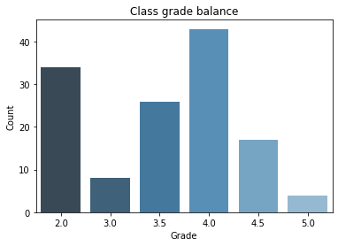

```
The following grade count is:
4.0    43
2.0    34
3.5    26
4.5    17
3.0     8
5.0     4
Name: GRADE, dtype: int64
```

```python
#grades count in the class
target_count = data['GRADE'].value_counts()
plt.figure()
plt.title('Class grade balance')
sns.barplot(target_count.index, target_count.values, palette="Blues_d")
plt.xlabel('Grade')
plt.ylabel('Count')
plt.show()

print("The following grade count is: ")
print(target_count)
```

```python
#final grades according to gender
dict_gender = {}
mask_male = data['GENDER']== 0
mask_female = data['GENDER']!=0
dict_gender['males'] = data['GRADE'][mask_male]
dict_gender['females'] = data['GRADE'][mask_female]

count = {}
for key in dict_gender:
    count[key] = dict_gender[key].value_counts()
```

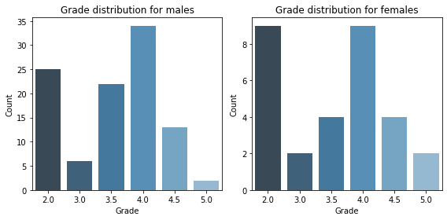

```python
rows, cols = choose_grid(len(dict_gender))
plt.figure()
fig, axs = plt.subplots(rows, cols, figsize=(cols*4, rows*4), squeeze=False)
i, j = 0, 0
n = 0
for key in dict_gender:
    axs[i, j].set_title('Grade distribution for %s'%key)
    axs[i, j].set_ylabel('Count')
    axs[i, j].set_xlabel('Grade')
    sns.barplot(count[key].index, count[key].values, ax=axs[i, j], palette='Blues_d')
    i, j = (i + 1, 0) if (n+1) % cols == 0 else (i, j + 1)
    n = n+1
fig.tight_layout()
plt.show()
```

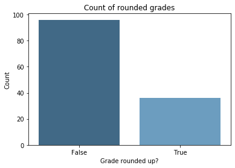

```
The following grade round count is:
False    96
True     36
Name: GRADE_UP, dtype: int64
```

```python
#count of grades rounded up or down
target_count_round = data['GRADE_UP'].value_counts()
plt.figure()
plt.title('Count of rounded grades')
sns.barplot(target_count_round.index, target_count_round.values, palette="Blues_d")
plt.xlabel('Grade rounded up?')
plt.ylabel('Count')
plt.show()

print("The following grade round count is: ")
print(target_count_round)
```

```python
def multiple_bar_chart(ax: plt.Axes, xvalues: list, yvalues: dict, title: str, xlabel: str, ylabel: str, percentage=False):

    ax.set_title(title)
    ax.set_xlabel(xlabel)
    ax.set_ylabel(ylabel)
    x = np.arange(len(xvalues))  # the label locations
    ax.set_xticks(x)
    ax.set_xticklabels(xvalues, fontsize='small')
    if percentage:
        ax.set_ylim(0.0, 1.0)
    width = 0.8  # the width of the bars
    step = width / len(yvalues)
    k = 0
    for name, y in yvalues.items():
        sns.barplot(x + k * step, y, step, label=name, palette="Blues_d")
        k += 1
    ax.legend(loc='lower center', ncol=len(yvalues), bbox_to_anchor=(0.5, -0.2), fancybox = True, shadow = True)
```

```python
#splitting datasets
y = data.pop('FINAL').values
#for building models, not all columns are required. irrelevant columns dropped
data_dropped = data.drop(labels = ['GRADE', 'GRADE_UP', 'AVERAGE'], axis = 1)
X = data_dropped.values
labels = pd.unique(y)

trainX, testX, trainY, testY = train_test_split(X, y, train_size = 0.7, stratify = y)
```

```python
def bar_chart(ax: plt.Axes, xvalues: list, yvalues: list, title: str, xlabel: str, ylabel: str, percentage=False):
    ax.set_title(title)
    ax.set_xlabel(xlabel)
    ax.set_ylabel(ylabel)
    ax.set_xticklabels(xvalues, rotation=90, fontsize='small')
    if percentage:
        ax.set_ylim(0.0, 1.0)
    sns.barplot(xvalues, yvalues, edgecolor='grey', palette="Blues_d")
```

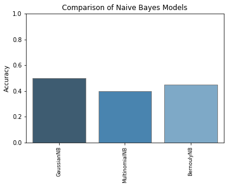

```python
#comparison of different classifiers from Naive Bayes classification
estimators = {'GaussianNB': GaussianNB(),
              'MultinomialNB': MultinomialNB(),
              'BernoulyNB': BernoulliNB()}

xvalues = []
yvalues = []
for classifier in estimators:
    xvalues.append(classifier)
    estimators[classifier].fit(trainX, trainY)
    predictedY = estimators[classifier].predict(testX)
    yvalues.append(metrics.accuracy_score(testY, predictedY))

plt.figure()
bar_chart(plt.gca(), xvalues, yvalues, 'Comparison of Naive Bayes Models', '', 'Accuracy', percentage=True)
plt.show()
```

```python
def multiple_line_chart(ax: plt.Axes, xvalues: list, yvalues: dict, title: str, xlabel: str, ylabel: str, percentage=False):
    legend: list = []
    ax.set_title(title)
    ax.set_xlabel(xlabel)
    ax.set_ylabel(ylabel)
    if percentage:
        ax.set_ylim(0.0, 1.0)

    for name, y in yvalues.items():
        ax.plot(xvalues, y)
        legend.append(name)
    ax.legend(legend, loc='best', fancybox = True, shadow = True)
```

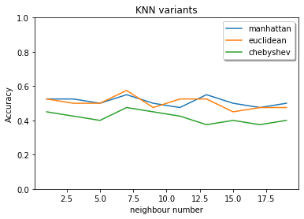

```python
neighbours = [1, 3, 5, 7, 9, 11, 13, 15, 17, 19]
dist = ['manhattan', 'euclidean', 'chebyshev']
values = {}
for d in dist:
    yvalues = []
    for n in neighbours:
        knn = KNeighborsClassifier(n_neighbors=n, metric=d)
        knn.fit(trainX, trainY)
        predictY = knn.predict(testX)
        yvalues.append(metrics.accuracy_score(testY, predictY))
    values[d] = yvalues

plt.figure()
multiple_line_chart(plt.gca(), neighbours, values, 'KNN variants', 'neighbour number', 'Accuracy', percentage=True)
plt.show()
```

Next, the decision tree method will be investigated. In this case, the author will investigate the influence of leaf samples and depth number on model accuracy. The minimum samples leaf is variable giving information on minimum number of samples required to be at a leaf node, while the max depths variable is the maximum depth of decision tree. What is more, two criteria methods will be presented. The criteria are:

- entropy
- gini The criteria differ in definition of impurity measurement but in most cases they result in very similar decision trees.

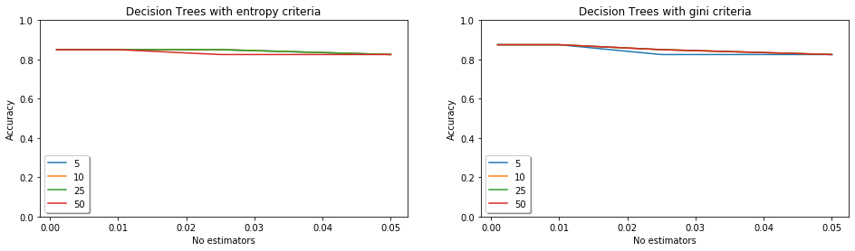

```python
min_samples_leaf = [.05, .025, .01, .0075, .005, .0025, .001]
max_depths = [5, 10, 25, 50]
criteria = ['entropy', 'gini']

plt.figure()
fig, axs = plt.subplots(1, 2, figsize=(16, 4), squeeze=False)
for k in range(len(criteria)):
    f = criteria[k]
    values = {}
    for d in max_depths:
        yvalues = []
        for n in min_samples_leaf:
            tree = DecisionTreeClassifier(min_samples_leaf=n, max_depth=d, criterion=f)
            tree.fit(trainX, trainY)
            predictY = tree.predict(testX)
            yvalues.append(metrics.accuracy_score(testY, predictY))
        values[d] = yvalues
    multiple_line_chart(axs[0, k], min_samples_leaf, values, 'Decision Trees with %s criteria'%f, 'No estimators',
                             'Accuracy', percentage=True)

plt.show()
```

As can be observed, both impurity criteria give similar results.

The last investigated method will be the method of random forests. A random forest is an estimator that fits a number of decision tree classifiers on various sub-samples of the dataset and uses averaging to improve the predictive accuracy and control over-fitting. Number of estimators is the number of trees in each forest, while max depths is the maximum depth of each decision tree. Max features variables gives the number of features to consider when looking for the best split of data. In this case, two features are investigated:

- sqrt - max_features=sqrt(n_features)
- log2 - max_features=log2(n_features)

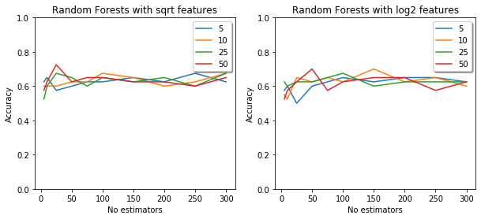

```python
n_estimators = [5, 10, 25, 50, 75, 100, 150, 200, 250, 300]
max_depths = [5, 10, 25, 50]
max_features = ['sqrt', 'log2']

plt.figure()
fig, axs = plt.subplots(1, 2, figsize=(10, 4), squeeze=False)
for k in range(len(max_features)):
    f = max_features[k]
    values = {}
    for d in max_depths:
        yvalues = []
        for n in n_estimators:
            randomforest = RandomForestClassifier(n_estimators=n, max_depth=d, max_features=f)
            randomforest.fit(trainX, trainY)
            predictY = randomforest.predict(testX)
            yvalues.append(metrics.accuracy_score(testY, predictY))
        values[d] = yvalues
    multiple_line_chart(axs[0, k], n_estimators, values, 'Random Forests with %s features'%f, 'No estimators',
                             'Accuracy', percentage=True)

plt.show()
```

As can be observed, the random forest method gives worse results than using singular decision trees. In conclusion, the decision tree method is the best method for modelling data from the given dataset.